# Zillow Home Value Index Analysis

#### NC Rental Market

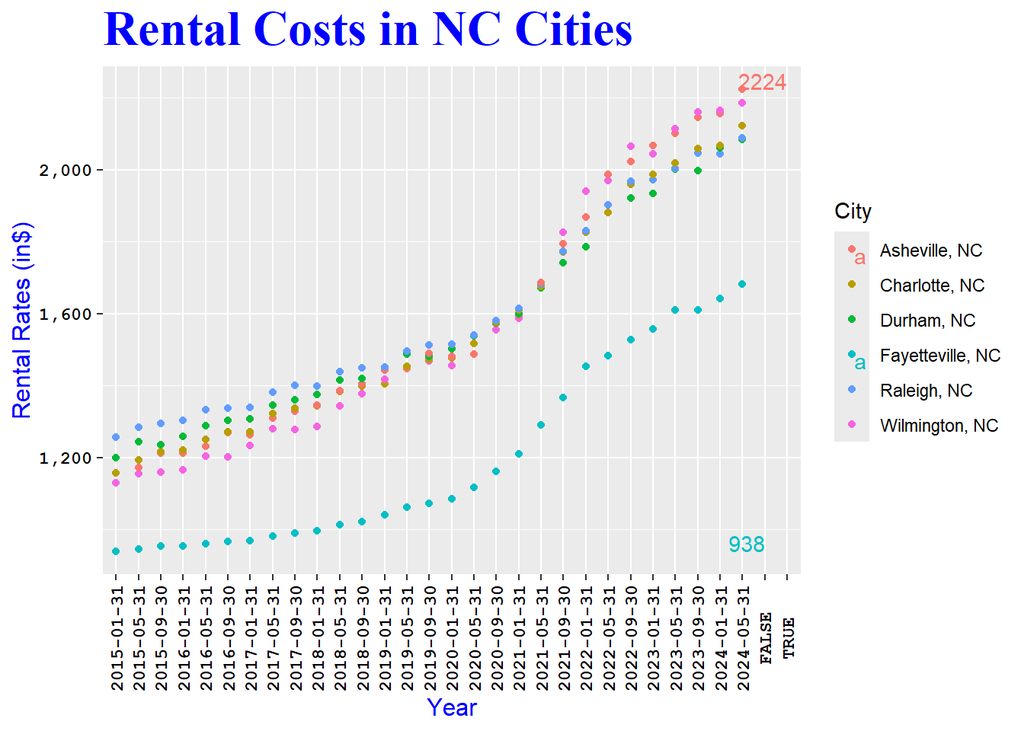

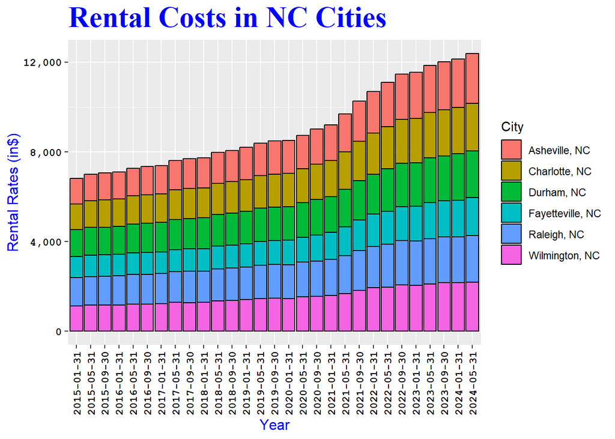

1. What has been the overall trend in the rental market around the state? Are there any cities that have not followed this trend?
   - **The overall trend has been an increase in the rental costs in the evaluated cities.**
2. Where is the most expensive city to rent in? Least expensive?
   - Currently the **most expensive** city to rent in is **Asheville** while the **least expensive** is **Fayetteville.**
3. You are trying decide between Wilmington and Asheville. Which market has the lowest rent?
   - **Wilmington** has lower rent than Asheville in 2017.

#### Home Values in Selected Rental Markets

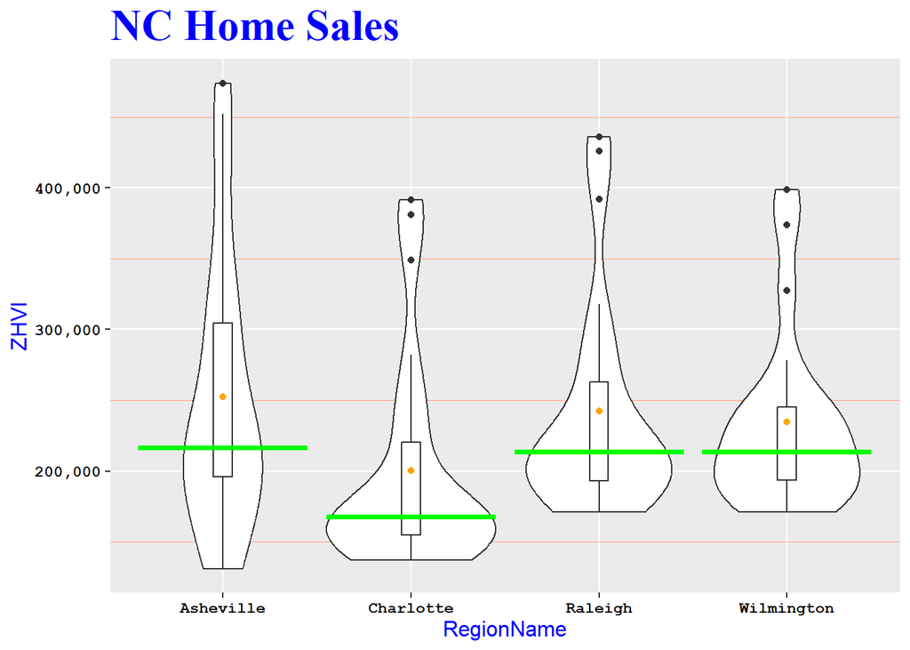

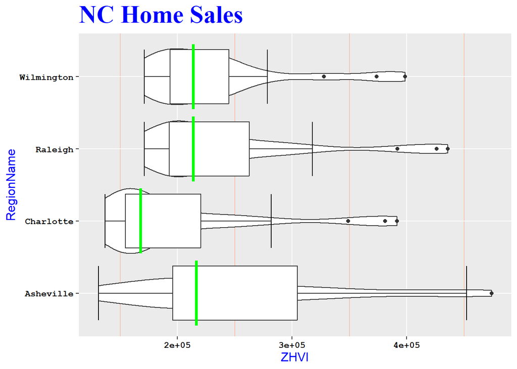

1. According to the results, which market has the lowest median price (represented as horizontal bar in box plot)?
   - **Charlotte** had the lowest median price.
2. The violin plot will show density meaning the wider the plot is, the more observations occur within that area. Which market has the most density around the median value of homes?
   - **Charlotte** has the largest density around the median value in that metro area.